# Import libraries

```python
import pandas as pd
import numpy as np
import seaborn as sns
import matplotlib.pyplot as plt
%matplotlib inline

import warnings
warnings.filterwarnings('ignore')
```

# Load Datasets

```python
train = pd.read_csv('../Datasets/ML online class/project/dataset/train.txt')
test = pd.read_csv('../Datasets/ML online class/project/dataset/test.txt')
```

# Copy of Dataset just in case we need it in future

```python
train_copy = train.copy()
test_copy = test.copy()
```

```python
# add column names to our data set

columns = (['duration'
,'protocol_type'
,'service'
,'flag'
,'src_bytes'
,'dst_bytes'
,'land'
,'wrong_fragment'
,'urgent'
,'hot'
,'num_failed_logins'
,'logged_in'
,'num_compromised'
,'root_shell'
,'su_attempted'
,'num_root'
,'num_file_creations'
,'num_shells'
,'num_access_files'
,'num_outbound_cmds'
,'is_host_login'
,'is_guest_login'
,'count'
,'srv_count'
,'serror_rate'
,'srv_serror_rate'
,'rerror_rate'
,'srv_rerror_rate'
,'same_srv_rate'
,'diff_srv_rate'
,'srv_diff_host_rate'
,'dst_host_count'
,'dst_host_srv_count'
,'dst_host_same_srv_rate'
,'dst_host_diff_srv_rate'
,'dst_host_same_src_port_rate'
,'dst_host_srv_diff_host_rate'
,'dst_host_serror_rate'
,'dst_host_srv_serror_rate'
,'dst_host_rerror_rate'
,'dst_host_srv_rerror_rate'
,'attack'
,'level'])
```

```python
# assigning the column names to the dataset
train.columns= columns
test.columns= columns
```

# Train and Test Dataset

```python
train.head()
```

|  | duration | protocol_type | service | flag | src_bytes | dst_bytes | land | wrong_fragment | urgent | hot | ... | dst_host_same_srv_rate | dst_host_diff_srv_rate | dst_host_same_src_port_rate | dst_host_srv_diff_host_rate | dst_host_serror_rate | dst_host_srv_serror_rate | dst_host_rerror_rate | dst_host_srv_rerror_rate | attack | level |
| --- | --- | --- | --- | --- | --- | --- | --- | --- | --- | --- | --- | --- | --- | --- | --- | --- | --- | --- | --- | --- | --- |
| 0 | 0 | udp | other | SF | 146 | 0 | 0 | 0 | 0 | 0 | ... | 0.00 | 0.60 | 0.88 | 0.00 | 0.00 | 0.00 | 0.0 | 0.00 | normal | 15 |
| 1 | 0 | tcp | private | S0 | 0 | 0 | 0 | 0 | 0 | 0 | ... | 0.10 | 0.05 | 0.00 | 0.00 | 1.00 | 1.00 | 0.0 | 0.00 | neptune | 19 |
| 2 | 0 | tcp | http | SF | 232 | 8153 | 0 | 0 | 0 | 0 | ... | 1.00 | 0.00 | 0.03 | 0.04 | 0.03 | 0.01 | 0.0 | 0.01 | normal | 21 |
| 3 | 0 | tcp | http | SF | 199 | 420 | 0 | 0 | 0 | 0 | ... | 1.00 | 0.00 | 0.00 | 0.00 | 0.00 | 0.00 | 0.0 | 0.00 | normal | 21 |
| 4 | 0 | tcp | private | REJ | 0 | 0 | 0 | 0 | 0 | 0 | ... | 0.07 | 0.07 | 0.00 | 0.00 | 0.00 | 0.00 | 1.0 | 1.00 | neptune | 21 |

5 rows × 43 columns

```python
test.head()
```

|  | duration | protocol_type | service | flag | src_bytes | dst_bytes | land | wrong_fragment | urgent | hot | ... | dst_host_same_srv_rate | dst_host_diff_srv_rate | dst_host_same_src_port_rate | dst_host_srv_diff_host_rate | dst_host_serror_rate | dst_host_srv_serror_rate | dst_host_rerror_rate | dst_host_srv_rerror_rate | attack | level |
| --- | --- | --- | --- | --- | --- | --- | --- | --- | --- | --- | --- | --- | --- | --- | --- | --- | --- | --- | --- | --- | --- |
| 0 | 0 | tcp | private | REJ | 0 | 0 | 0 | 0 | 0 | 0 | ... | 0.00 | 0.06 | 0.00 | 0.00 | 0.00 | 0.0 | 1.00 | 1.00 | neptune | 21 |
| 1 | 2 | tcp | ftp_data | SF | 12983 | 0 | 0 | 0 | 0 | 0 | ... | 0.61 | 0.04 | 0.61 | 0.02 | 0.00 | 0.0 | 0.00 | 0.00 | normal | 21 |
| 2 | 0 | icmp | eco_i | SF | 20 | 0 | 0 | 0 | 0 | 0 | ... | 1.00 | 0.00 | 1.00 | 0.28 | 0.00 | 0.0 | 0.00 | 0.00 | saint | 15 |
| 3 | 1 | tcp | telnet | RSTO | 0 | 15 | 0 | 0 | 0 | 0 | ... | 0.31 | 0.17 | 0.03 | 0.02 | 0.00 | 0.0 | 0.83 | 0.71 | mscan | 11 |
| 4 | 0 | tcp | http | SF | 267 | 14515 | 0 | 0 | 0 | 0 | ... | 1.00 | 0.00 | 0.01 | 0.03 | 0.01 | 0.0 | 0.00 | 0.00 | normal | 21 |

5 rows × 43 columns

# Descriptive Analysis

```python
train.shape, test.shape
```

```
((125972, 43), (22543, 43))
```

```python
train.info()
```

```
<class 'pandas.core.frame.DataFrame'>
RangeIndex: 125972 entries, 0 to 125971
Data columns (total 43 columns):
 #   Column                       Non-Null Count   Dtype
---  ------                       --------------   -----
 0   duration                     125972 non-null  int64
 1   protocol_type                125972 non-null  object
 2   service                      125972 non-null  object
 3   flag                         125972 non-null  object
 4   src_bytes                    125972 non-null  int64
 5   dst_bytes                    125972 non-null  int64
 6   land                         125972 non-null  int64
 7   wrong_fragment               125972 non-null  int64
 8   urgent                       125972 non-null  int64
 9   hot                          125972 non-null  int64
```

[output cut: 35 more lines]

```python
train.isnull().sum()
```

```
duration                       0
protocol_type                  0
service                        0
flag                           0
src_bytes                      0
dst_bytes                      0
land                           0
wrong_fragment                 0
urgent                         0
hot                            0
num_failed_logins              0
logged_in                      0
num_compromised                0
root_shell                     0
su_attempted                   0
num_root                       0
num_file_creations             0
num_shells                     0
num_access_files               0
num_outbound_cmds              0
is_host_login                  0
is_guest_login                 0
count                          0
srv_count                      0
serror_rate                    0
srv_serror_rate                0
rerror_rate                    0
srv_rerror_rate                0
same_srv_rate                  0
diff_srv_rate                  0
srv_diff_host_rate             0
dst_host_count                 0
dst_host_srv_count             0
dst_host_same_srv_rate         0
dst_host_diff_srv_rate         0
dst_host_same_src_port_rate    0
dst_host_srv_diff_host_rate    0
dst_host_serror_rate           0
dst_host_srv_serror_rate       0
dst_host_rerror_rate           0
dst_host_srv_rerror_rate       0
attack                         0
level                          0
dtype: int64
```

```python
test.isnull().sum()
```

```
duration                       0
protocol_type                  0
service                        0
flag                           0
src_bytes                      0
dst_bytes                      0
land                           0
wrong_fragment                 0
urgent                         0
hot                            0
num_failed_logins              0
logged_in                      0
num_compromised                0
root_shell                     0
su_attempted                   0
num_root                       0
num_file_creations             0
num_shells                     0
num_access_files               0
num_outbound_cmds              0
is_host_login                  0
is_guest_login                 0
count                          0
srv_count                      0
serror_rate                    0
srv_serror_rate                0
rerror_rate                    0
srv_rerror_rate                0
same_srv_rate                  0
diff_srv_rate                  0
srv_diff_host_rate             0
dst_host_count                 0
dst_host_srv_count             0
dst_host_same_srv_rate         0
dst_host_diff_srv_rate         0
dst_host_same_src_port_rate    0
dst_host_srv_diff_host_rate    0
dst_host_serror_rate           0
dst_host_srv_serror_rate       0
dst_host_rerror_rate           0
dst_host_srv_rerror_rate       0
attack                         0
level                          0
dtype: int64
```

```python
# description on integer columns
train.describe()
```

|  | duration | src_bytes | dst_bytes | land | wrong_fragment | urgent | hot | num_failed_logins | logged_in | num_compromised | ... | dst_host_srv_count | dst_host_same_srv_rate | dst_host_diff_srv_rate | dst_host_same_src_port_rate | dst_host_srv_diff_host_rate | dst_host_serror_rate | dst_host_srv_serror_rate | dst_host_rerror_rate | dst_host_srv_rerror_rate | level |
| --- | --- | --- | --- | --- | --- | --- | --- | --- | --- | --- | --- | --- | --- | --- | --- | --- | --- | --- | --- | --- | --- |
| count | 125972.000000 | 1.259720e+05 | 1.259720e+05 | 125972.000000 | 125972.000000 | 125972.000000 | 125972.000000 | 125972.000000 | 125972.000000 | 125972.000000 | ... | 125972.000000 | 125972.000000 | 125972.000000 | 125972.000000 | 125972.000000 | 125972.000000 | 125972.000000 | 125972.000000 | 125972.000000 | 125972.000000 |
| mean | 287.146929 | 4.556710e+04 | 1.977927e+04 | 0.000198 | 0.022688 | 0.000111 | 0.204411 | 0.001222 | 0.395739 | 0.279253 | ... | 115.653725 | 0.521244 | 0.082952 | 0.148379 | 0.032543 | 0.284455 | 0.278487 | 0.118832 | 0.120241 | 19.504056 |
| std | 2604.525522 | 5.870354e+06 | 4.021285e+06 | 0.014086 | 0.253531 | 0.014366 | 2.149977 | 0.045239 | 0.489011 | 23.942137 | ... | 110.702886 | 0.448950 | 0.188922 | 0.308998 | 0.112564 | 0.444785 | 0.445670 | 0.306559 | 0.319460 | 2.291512 |
| min | 0.000000 | 0.000000e+00 | 0.000000e+00 | 0.000000 | 0.000000 | 0.000000 | 0.000000 | 0.000000 | 0.000000 | 0.000000 | ... | 0.000000 | 0.000000 | 0.000000 | 0.000000 | 0.000000 | 0.000000 | 0.000000 | 0.000000 | 0.000000 | 0.000000 |
| 25% | 0.000000 | 0.000000e+00 | 0.000000e+00 | 0.000000 | 0.000000 | 0.000000 | 0.000000 | 0.000000 | 0.000000 | 0.000000 | ... | 10.000000 | 0.050000 | 0.000000 | 0.000000 | 0.000000 | 0.000000 | 0.000000 | 0.000000 | 0.000000 | 18.000000 |
| 50% | 0.000000 | 4.400000e+01 | 0.000000e+00 | 0.000000 | 0.000000 | 0.000000 | 0.000000 | 0.000000 | 0.000000 | 0.000000 | ... | 63.000000 | 0.510000 | 0.020000 | 0.000000 | 0.000000 | 0.000000 | 0.000000 | 0.000000 | 0.000000 | 20.000000 |
| 75% | 0.000000 | 2.760000e+02 | 5.160000e+02 | 0.000000 | 0.000000 | 0.000000 | 0.000000 | 0.000000 | 1.000000 | 0.000000 | ... | 255.000000 | 1.000000 | 0.070000 | 0.060000 | 0.020000 | 1.000000 | 1.000000 | 0.000000 | 0.000000 | 21.000000 |
| max | 42908.000000 | 1.379964e+09 | 1.309937e+09 | 1.000000 | 3.000000 | 3.000000 | 77.000000 | 5.000000 | 1.000000 | 7479.000000 | ... | 255.000000 | 1.000000 | 1.000000 | 1.000000 | 1.000000 | 1.000000 | 1.000000 | 1.000000 | 1.000000 | 21.000000 |

8 rows × 39 columns

```python
# description on string columns
train.describe(include='O')
```

|  | protocol_type | service | flag | attack |
| --- | --- | --- | --- | --- |
| count | 125972 | 125972 | 125972 | 125972 |
| unique | 3 | 70 | 11 | 23 |
| top | tcp | http | SF | normal |
| freq | 102688 | 40338 | 74944 | 67342 |

```python
# description on string columns
test.describe(include='O')
```

|  | protocol_type | service | flag | attack |
| --- | --- | --- | --- | --- |
| count | 22543 | 22543 | 22543 | 22543 |
| unique | 3 | 64 | 11 | 38 |
| top | tcp | http | SF | normal |
| freq | 18879 | 7853 | 14875 | 9711 |

# Combining Train and Test Datasets

we observed that in train and test data we have different number of unique elements so, we will combine the train and test data and wewill do preprocessing. and after preprocessing we will again separete data

```python
df = pd.concat([train, test], axis=0, ignore_index=True)
```

```python
df.shape
```

```
(148515, 43)
```

```python
df.describe(include = 'O')
```

|  | protocol_type | service | flag | attack |
| --- | --- | --- | --- | --- |
| count | 148515 | 148515 | 148515 | 148515 |
| unique | 3 | 70 | 11 | 40 |
| top | tcp | http | SF | normal |
| freq | 121567 | 48191 | 89819 | 77053 |

```python
df.attack.unique() # if attack(nornal)  = good else bad
```

```
array(['normal', 'neptune', 'warezclient', 'ipsweep', 'portsweep',
       'teardrop', 'nmap', 'satan', 'smurf', 'pod', 'back',
       'guess_passwd', 'ftp_write', 'multihop', 'rootkit',
       'buffer_overflow', 'imap', 'warezmaster', 'phf', 'land',
       'loadmodule', 'spy', 'perl', 'saint', 'mscan', 'apache2',
       'snmpgetattack', 'processtable', 'httptunnel', 'ps', 'snmpguess',
       'mailbomb', 'named', 'sendmail', 'xterm', 'worm', 'xlock',
       'xsnoop', 'sqlattack', 'udpstorm'], dtype=object)
```

If attack type is **nornal** then its **good** condition otherwise **bad** so w'll do **binary classification** but there are also different categories of attacks as below:

| NO | Attack Type | Attack Name |
| --- | --- | --- |
| 1 | **DOS** | Back, land, Neptune, pod, smurf, teardrop |
| 2 | **User to Root Attacks** | Buffor_overflow, loadmodule, perl, rootkit |
| 3 | **Remote to Local Attacks** | ftp_write, guess_passwd, imap, multihop, phf, spy, warezclient |
| 4 | **Probes** | Satan, ipsweep, nmap, portsweep |

```python
# this function is used to map attack types as above table

def attack_type(attack):
    if attack in ['back', 'land', 'neptune', 'pod', 'smurf', 'teardrop']:
        return 1
    elif attack in ['buffor_overflow', 'loadmodule', 'perl', 'rootkit']:
        return 2
    elif attack in ['ftp_write', 'guess_passwd', 'imap', 'multihop', 'phf', 'spy', 'warezclient']:
        return 3
    elif attack in ['satan', 'ipsweep', 'nmap', 'portsweep']:
        return 4
    else:
        return 0
```

```python
# we created new feature for attack [0,1,2,3,4] multiclass-classification
df['attack_multi_class'] = df.attack.apply(attack_type)
```

```python
# we created new feature for binary classifiaction
df['attack_binary_class'] = df.attack.map(lambda x:0 if x=='normal' else 1)
```

```python
# displaying newly created features
df[['attack_multi_class', 'attack_binary_class']].head(20)
```

|  | attack_multi_class | attack_binary_class |
| --- | --- | --- |
| 0 | 0 | 0 |
| 1 | 1 | 1 |
| 2 | 0 | 0 |
| 3 | 0 | 0 |
| 4 | 1 | 1 |
| 5 | 1 | 1 |
| 6 | 1 | 1 |
| 7 | 1 | 1 |
| 8 | 1 | 1 |
| 9 | 1 | 1 |
| 10 | 1 | 1 |
| 11 | 0 | 0 |
| 12 | 3 | 1 |
| 13 | 1 | 1 |
| 14 | 1 | 1 |
| 15 | 0 | 0 |
| 16 | 4 | 1 |
| 17 | 0 | 0 |
| 18 | 0 | 0 |
| 19 | 1 | 1 |

```python
df.shape
```

```
(148515, 45)
```

# Lable Encoding

### 1) protocol_type 2) service 3) flag

```python
from sklearn.preprocessing import LabelEncoder
```

```python
le = LabelEncoder()
```

### 1) Protocol_type

```python
df.protocol_type = le.fit_transform(df.protocol_type)
```

### 2) Service

```python
df.service = le.fit_transform(df.service)
```

### 3) Flag

```python
df.flag = le.fit_transform(df.flag)
```

we created two feature from attack one for binary classification and one for multiclass classification so we drop attack column

```python
df.drop('attack', 1, inplace=True)
```

# Separate datasets

```python
train_enc = df.iloc[:125972, :]
test_enc = df.iloc[125972:, :]
```

```python
train_enc.shape, test_enc.shape
```

```
((125972, 44), (22543, 44))
```

**We will analyse features one by one**

```python
df.columns
```

```
Index(['duration', 'protocol_type', 'service', 'flag', 'src_bytes',
       'dst_bytes', 'land', 'wrong_fragment', 'urgent', 'hot',
       'num_failed_logins', 'logged_in', 'num_compromised', 'root_shell',
       'su_attempted', 'num_root', 'num_file_creations', 'num_shells',
       'num_access_files', 'num_outbound_cmds', 'is_host_login',
       'is_guest_login', 'count', 'srv_count', 'serror_rate',
       'srv_serror_rate', 'rerror_rate', 'srv_rerror_rate', 'same_srv_rate',
       'diff_srv_rate', 'srv_diff_host_rate', 'dst_host_count',
       'dst_host_srv_count', 'dst_host_same_srv_rate',
       'dst_host_diff_srv_rate', 'dst_host_same_src_port_rate',
       'dst_host_srv_diff_host_rate', 'dst_host_serror_rate',
       'dst_host_srv_serror_rate', 'dst_host_rerror_rate',
       'dst_host_srv_rerror_rate', 'level', 'attack_multi_class',
       'attack_binary_class'],
      dtype='object')
```

```python
# this function separete discrete and continuouse columns
def discrete_continuos(df):
    features = df.columns
    des_col = []
    conti_col = []
    for feature in features:
        size = len(df[feature].unique())
        if size<15:
            des_col.append(feature)
        else:
            conti_col.append(feature)
        print(feature.ljust(30, ' '), size)
    return des_col, conti_col
```

```python
des_col, conti_col = discrete_continuos(df)
```

```
duration                       3424
protocol_type                  3
service                        70
flag                           11
src_bytes                      3601
dst_bytes                      10401
land                           2
wrong_fragment                 3
urgent                         4
hot                            29
num_failed_logins              6
logged_in                      2
num_compromised                96
root_shell                     2
su_attempted                   3
num_root                       91
num_file_creations             36
num_shells                     4
num_access_files               10
num_outbound_cmds              1
is_host_login                  2
is_guest_login                 2
count                          512
srv_count                      512
serror_rate                    99
srv_serror_rate                94
rerror_rate                    98
srv_rerror_rate                95
same_srv_rate                  101
diff_srv_rate                  101
srv_diff_host_rate             87
dst_host_count                 256
dst_host_srv_count             256
dst_host_same_srv_rate         101
dst_host_diff_srv_rate         101
dst_host_same_src_port_rate    101
dst_host_srv_diff_host_rate    75
dst_host_serror_rate           101
dst_host_srv_serror_rate       101
dst_host_rerror_rate           101
dst_host_srv_rerror_rate       101
level                          22
attack_multi_class             5
attack_binary_class            2
```

```python
# discrete columns
des_col
```

```
['protocol_type',
 'flag',
 'land',
 'wrong_fragment',
 'urgent',
 'num_failed_logins',
 'logged_in',
 'root_shell',
 'su_attempted',
 'num_shells',
 'num_access_files',
 'num_outbound_cmds',
 'is_host_login',
 'is_guest_login',
 'attack_multi_class',
 'attack_binary_class']
```

```python
# continuouse columns
conti_col
```

```
['duration',
 'service',
 'src_bytes',
 'dst_bytes',
 'hot',
 'num_compromised',
 'num_root',
 'num_file_creations',
 'count',
 'srv_count',
 'serror_rate',
 'srv_serror_rate',
 'rerror_rate',
 'srv_rerror_rate',
 'same_srv_rate',
 'diff_srv_rate',
 'srv_diff_host_rate',
 'dst_host_count',
 'dst_host_srv_count',
 'dst_host_same_srv_rate',
 'dst_host_diff_srv_rate',
 'dst_host_same_src_port_rate',
 'dst_host_srv_diff_host_rate',
 'dst_host_serror_rate',
 'dst_host_srv_serror_rate',
 'dst_host_rerror_rate',
 'dst_host_srv_rerror_rate',
 'level']
```

```python
df.info()
```

```
<class 'pandas.core.frame.DataFrame'>
RangeIndex: 148515 entries, 0 to 148514
Data columns (total 44 columns):
 #   Column                       Non-Null Count   Dtype
---  ------                       --------------   -----
 0   duration                     148515 non-null  int64
 1   protocol_type                148515 non-null  int32
 2   service                      148515 non-null  int32
 3   flag                         148515 non-null  int32
 4   src_bytes                    148515 non-null  int64
 5   dst_bytes                    148515 non-null  int64
 6   land                         148515 non-null  int64
 7   wrong_fragment               148515 non-null  int64
 8   urgent                       148515 non-null  int64
 9   hot                          148515 non-null  int64
```

[output cut: 36 more lines]

```python
train_enc.shape, test_enc.shape
```

```
((125972, 44), (22543, 44))
```

# Data Visualisation

### 1) Discrete 2) continuous

### 1) Discrete

```python
# this function is used to visualise the discrete columns
def discrete_plot(df, df1, feature):
    plt.figure(figsize=(15, 5))

    plt.subplot(1,2,1)
    sns.countplot(x=feature, data=df)

    plt.subplot(1,2,2)
    sns.countplot(x=feature, data=df1)

    plt.show()

# this function is used to visualise the continuous columns
def continuous_plot(df, df1, feature):
    plt.figure(figsize=(15, 5))
    plt.subplot(1,2,1)
    sns.distplot(df[feature])

    plt.subplot(1,2,2)
    sns.distplot(df1[feature])
    plt.show()
```

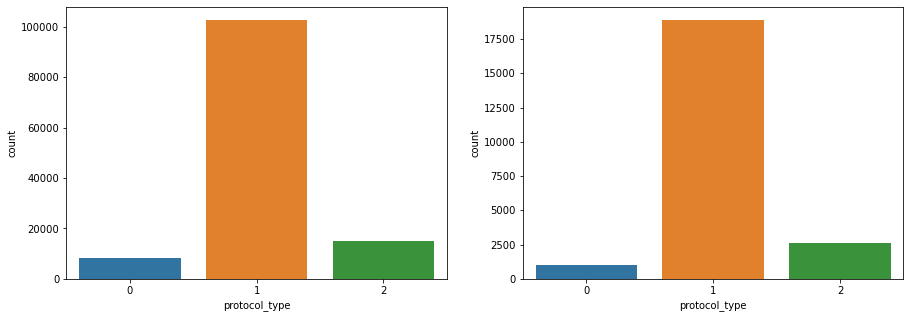

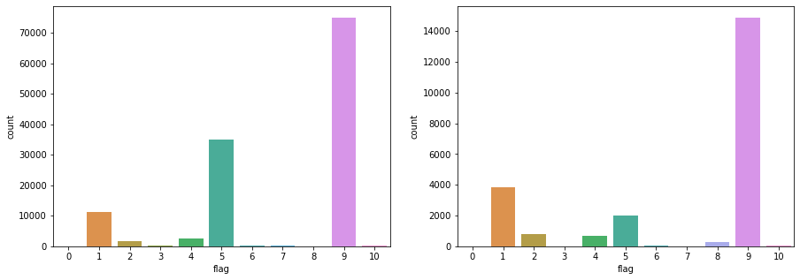

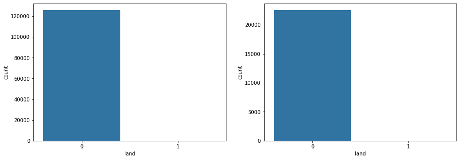

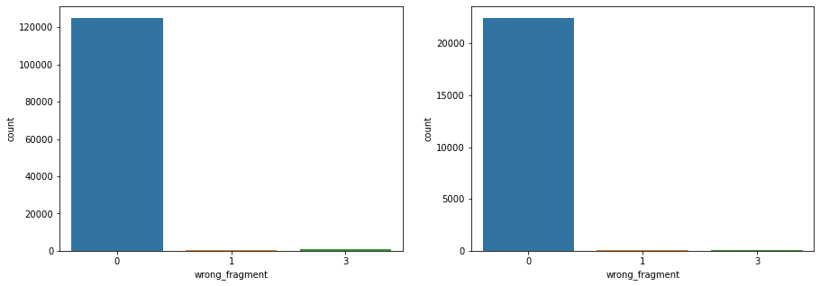

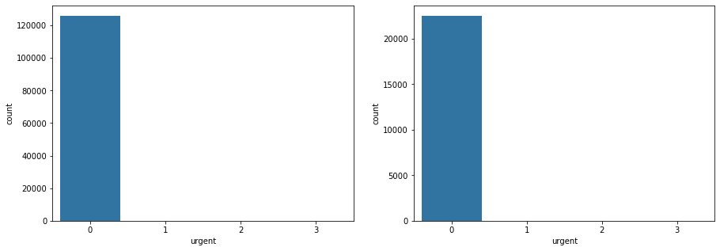

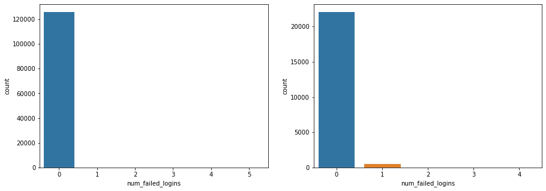

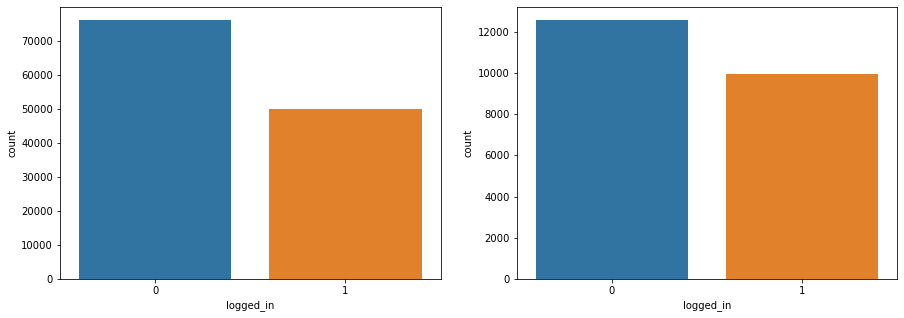

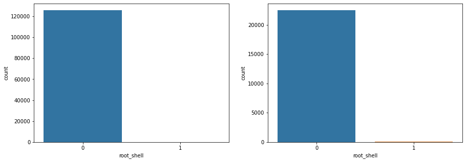

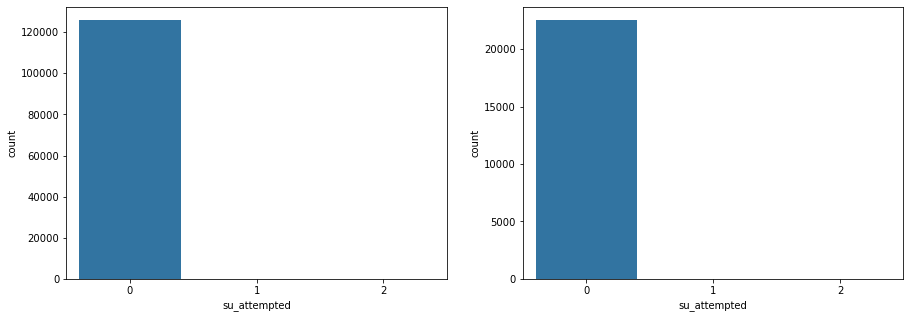

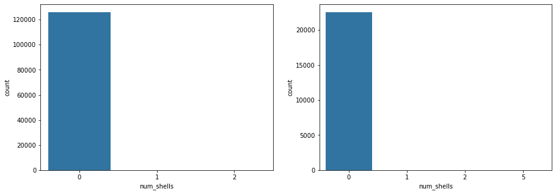

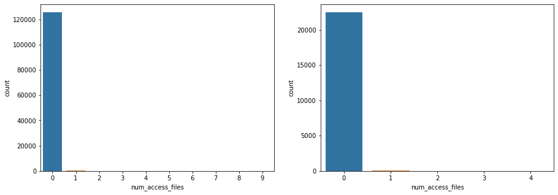

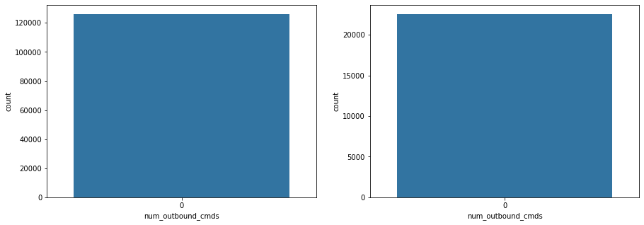

[4 more figures not shown]

```python
# visualising the discrete columns train vs test

for feature in des_col:
    discrete_plot(train_enc, test_enc, feature)
```

```python
# land, wrong fragment , urgent, numfailed logins, roo shell, suattempted, numshells, numaccessfiles, numoutboundcmds, is host login, is guest login
# train_enc.drop(['land', 'wrong_fragment', 'urgent', 'num_failed_logins', 'root_shell',
#                               'su_attempted', 'num_shells', 'num_access_files', 'num_outbound_cmds', 'is_host_login',
#                               'is_guest_login'], axis=1, inplace=True)
# test_enc.drop(['land', 'wrong_fragment', 'urgent', 'num_failed_logins', 'root_shell',
#                               'su_attempted', 'num_shells', 'num_access_files', 'num_outbound_cmds', 'is_host_login',
#                               'is_guest_login'], axis=1, inplace=True)
```